# 4.3 — Categorical Data & Interactions — R Practice

Author

Answer Key

Published

November 9, 2022

# Required Packages & Data

Load all the required packages we will use (**note I have installed them already into the cloud project**) by running (clicking the green play button) the chunk below:

```r
library(tidyverse) # your friend and mine
library(broom) # for tidy regression
library(modelsummary) # for nice regression tables
```

We are returning to the speeding tickets data that we began to explore in [R Practice 4.1 on Multivariate Regression](http://metricsf22.classes.ryansafner.com/r/4.1-r-practice). Download and read in (`read_csv`) the data below.

- [`speeding_tickets.csv`](http://metricsf21.classes.ryansafner.com/data/speeding_tickets.csv)

```r
# run or edit this chunk (if you want to rename the data)

# read in data from url
# or you could download and upload it to this project instead
speed <- read_csv("https://metricsf22.classes.ryansafner.com/files/data/speeding_tickets.csv")
```

This data comes from a paper by Makowsky and Strattman (2009) that we will examine later. Even though state law sets a formula for tickets based on how fast a person was driving, police officers in practice often deviate from that formula. This dataset includes information on all traffic stops. An amount for the fine is given only for observations in which the police officer decided to assess a fine. There are a number of variables in this dataset, but the one’s we’ll look at are:

| Variable | Description |
| --- | --- |
| `Amount` | Amount of fine (in dollars) assessed for speeding |
| `Age` | Age of speeding driver (in years) |
| `MPHover` | Miles per hour over the speed limit |
| `Black` | Dummy $=1$ if driver was black, $=0$ if not |
| `Hispanic` | Dummy $=1$ if driver was Hispanic, $=0$ if not |
| `Female` | Dummy $=1$ if driver was female, $=0$ if not |
| `OutTown` | Dummy $=1$ if driver was not from local town, $=0$ if not |
| `OutState` | Dummy $=1$ if driver was not from local state, $=0$ if not |
| `StatePol` | Dummy $=1$ if driver was stopped by State Police, $=0$ if stopped by other (local) |

We want to explore **who gets fines, and how much**. We’ll come back to the other variables (which are categorical) in this dataset in later lessons.

## Question 1

We will have to do a little more cleaning to get some of the data into a more usable form.

### Part A

Inspect the data with `str()` or `head()` or `glimpse()` to see what it looks like.

```r
# type your code below in this chunk
str(speed)
```

```
spc_tbl_ [68,357 × 9] (S3: spec_tbl_df/tbl_df/tbl/data.frame)
 $ Black   : num [1:68357] 0 0 0 0 0 0 0 0 0 0 ...
 $ Hispanic: num [1:68357] 0 0 0 0 0 0 0 0 0 0 ...
 $ Female  : num [1:68357] 1 1 1 0 0 0 1 0 1 0 ...
 $ Amount  : num [1:68357] NA NA NA NA NA NA NA NA NA NA ...
 $ MPHover : num [1:68357] 14 15 15 13 12 17 15 15 15 15 ...
 $ Age     : num [1:68357] 22 43 32 24 54 30 18 53 51 33 ...
 $ OutTown : num [1:68357] 1 1 0 1 1 1 0 0 1 1 ...
 $ OutState: num [1:68357] 0 0 0 0 0 0 0 0 0 0 ...
 $ StatePol: num [1:68357] 0 0 0 0 0 0 0 0 0 0 ...
 - attr(*, "spec")=
  .. cols(
  ..   Black = col_double(),
  ..   Hispanic = col_double(),
  ..   Female = col_double(),
  ..   Amount = col_double(),
  ..   MPHover = col_double(),
  ..   Age = col_double(),
  ..   OutTown = col_double(),
  ..   OutState = col_double(),
  ..   StatePol = col_double()
  .. )
 - attr(*, "problems")=<externalptr>
```

What `class` of variable are `Black`, `Hispanic`, `Female`, `OutTown`, and `OutState`?

They are all `num` - `numeric` variables.

### Part B

Notice that when importing the data from the `.csv` file, `R` interpreted these variables as `numeric` (`num`) or `double` (`dbl`), but we want them to be `factor` (`fct`) variables, to ensure `R` recognizes that there are two groups (categories), 0 and 1.

You could convert the variables one at a time to factors using `as.factor()` inside a `mutate()` command. But there is a special `mutate()` command that allows you to apply a transformation (like changing a variable’s class to `factor`), which you can run the following chunk to execute:

```r
# run or edit this chunk
speed <- speed %>%
  mutate_at(c("Black", "Hispanic", "Female", "OutTown", "OutState"), factor)

speed
```

| Black | Hispanic | Female | Amount | MPHover | Age | OutTown | OutState | StatePol |
| --- | --- | --- | --- | --- | --- | --- | --- | --- |
| 0 | 0 | 1 | NA | 14 | 22 | 1 | 0 | 0 |
| 0 | 0 | 1 | NA | 15 | 43 | 1 | 0 | 0 |
| 0 | 0 | 1 | NA | 15 | 32 | 0 | 0 | 0 |
| 0 | 0 | 0 | NA | 13 | 24 | 1 | 0 | 0 |
| 0 | 0 | 0 | NA | 12 | 54 | 1 | 0 | 0 |
| 0 | 0 | 0 | NA | 17 | 30 | 1 | 0 | 0 |
| 0 | 0 | 1 | NA | 15 | 18 | 0 | 0 | 0 |
| 0 | 0 | 0 | NA | 15 | 53 | 0 | 0 | 0 |
| 0 | 0 | 1 | NA | 15 | 51 | 1 | 0 | 0 |
| 0 | 0 | 0 | NA | 15 | 33 | 1 | 0 | 0 |

[output cut: 9990 more lines]

Confirm that these are now `factor` (`fct`) variables.

### Part C

Finally, recall from the last time we worked with this data that there are many `NA`s for `Amount` (these are people that were stopped but did not receive a fine). Let’s `filter()` only those observations for which `Amount` is a positive number, and save this in your dataframe (assign and overwrite it, or make a new dataframe).

```r
# run or edit this chunk

# see the NAs
speed %>%
  select(Amount) %>%
  summary()
```

```
     Amount
 Min.   :  3
 1st Qu.: 75
 Median :115
 Mean   :122
 3rd Qu.:155
 Max.   :725
 NA's   :36683
```

```r
# overwrite data to keep only positive Amounts
speed <- speed %>%
  filter(Amount > 0)

# see there are no more NAs
speed %>%
  select(Amount) %>%
  summary()
```

```
     Amount
 Min.   :  3
 1st Qu.: 75
 Median :115
 Mean   :122
 3rd Qu.:155
 Max.   :725
```

## Question 2

Does the sex of the driver affect the fine? There’s already a dummy variable `Female` in the dataset, so create a scatterplot between `Amount` (as `y`) and Female (as `x`).

Hint: Use `geom_jitter()` instead of `geom_point()` to better see the points, and play around with `width` settings inside `geom_jitter()`

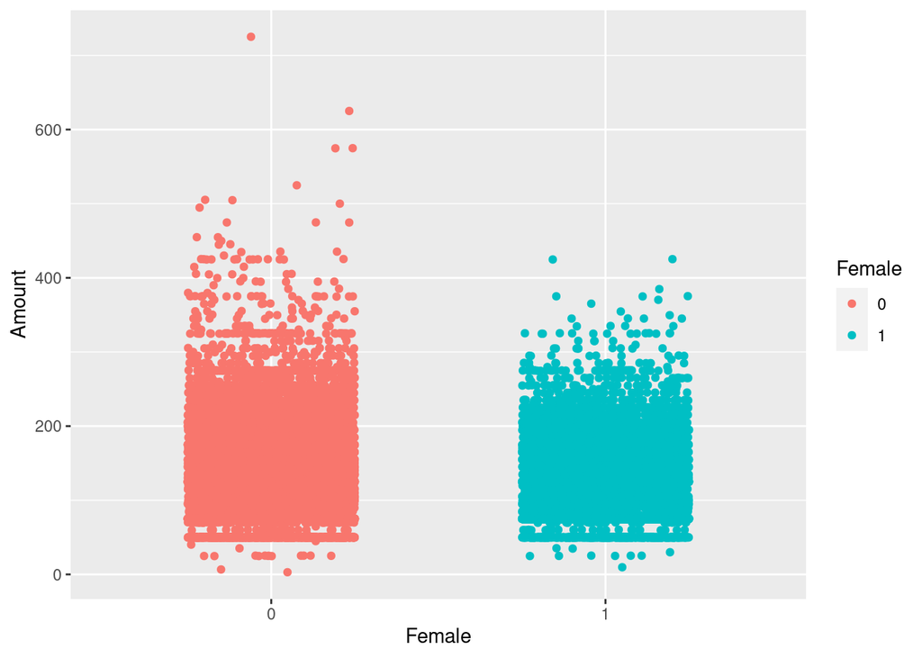

```r
# type your code below in this chunk
ggplot(data = speed)+
  aes(x = Female,
      y = Amount,
      color = Female)+
  geom_jitter(width = 0.25)
```

As an aside, if you had not made `Female` a `factor`, and kept it `numeric`, it might alter the plot.

You can make `Female` a `factor` just for plotting purposes by setting `aes(x = as.factor(Female))` inside the `aes()` layer of your `ggplot()` code.

## Question 3

Now let’s start looking at the distribution conditionally to find the different group means.

### Part A

Find the mean and standard deviation of `Amount` for *male* drivers and again for *female* drivers.

Hint: properly `filter()` the data and then use the `summarize()` command.

```r
# Summarize for Men

# I'll save as male_summary, since
# we'll use this in next part

male_summary <- speed %>%
  filter(Female == 0) %>%
  summarize(mean = mean(Amount),
            sd = sd(Amount))

# look at it
male_summary
```

| mean | sd |
| --- | --- |
| 124.6654 | 58.28387 |

```r
# Summarize for Women

# I'll save as female_summary, since
# we'll use this in next part

female_summary <- speed %>%
  filter(Female == 1) %>%
  summarize(mean = mean(Amount),
            sd = sd(Amount))

# look at it
female_summary
```

| mean | sd |
| --- | --- |
| 116.726 | 51.48665 |

### Part B

What is the difference between the average Amount for Males and Females?

```r
# we can do this with R using our summary dataframes we made last part

male_avg <- male_summary %>%
  pull(mean) # pull extracts the value

male_avg #check
```

```
[1] 124.6654
```

```r
female_avg <- female_summary %>%
  pull(mean)

female_avg #check
```

```
[1] 116.726
```

```r
# difference
male_avg - female_avg
```

```
[1] 7.939397
```

Males get $ 124.67 and Females get $ 116.73, so Males get $ 7.94 higher fines on average than Females.

### Part C

We did not go over how to do this in class, but you can run a **t-test for the difference in group means** to see if the difference is statistically significant. The syntax is similar for a regression:

```r
# run or edit this chunk
t.test(Amount ~ Female,
       data = speed)
```

```
    Welch Two Sample t-test

data:  Amount by Female
t = 12.356, df = 23400, p-value < 2.2e-16
alternative hypothesis: true difference in means between group 0 and group 1 is not equal to 0
95 percent confidence interval:
 6.679941 9.198853
sample estimates:
mean in group 0 mean in group 1
       124.6654        116.7260
```

Is there a statistically significant difference between `Amount` for male and female drivers? Hint: this is like any hypothesis test. Here $H_0: \text{difference}=0$. A $t$-value needs to be large enough to be greater than a critical value of $t$. Check the $p$-value and see if it is less than our standard of $\alpha=0.05.$

Yes, there is a statistically significant difference in fine amounts between men and women. The p-value is very very small, certainly smaller than 0.05. So we have sufficient evidence to reject the null hypothesis (of no difference).

## Question 4

### Part A

Now run the following regression to ensure we get the same result as the t-test.

$$\widehat{\text{Amount}}_i=\hat{\beta_0}+\hat{\beta_1} \, \text{Female}_i$$

```r
female_reg <- lm(Amount ~ Female, data = speed)
summary(female_reg)
```

```
Call:
lm(formula = Amount ~ Female, data = speed)

Residuals:
    Min      1Q  Median      3Q     Max
-121.67  -49.67   -6.73   30.33  600.33

Coefficients:
            Estimate Std. Error t value Pr(>|t|)
(Intercept) 124.6654     0.3857  323.23   <2e-16 ***
Female1      -7.9394     0.6698  -11.85   <2e-16 ***
---
Signif. codes:  0 '***' 0.001 '**' 0.01 '*' 0.05 '.' 0.1 ' ' 1

Residual standard error: 56.12 on 31672 degrees of freedom
Multiple R-squared:  0.004416,  Adjusted R-squared:  0.004385
F-statistic: 140.5 on 1 and 31672 DF,  p-value: < 2.2e-16
```

```r
# can also do broom's tidy()
tidy(female_reg)
```

| term | estimate | std.error | statistic | p.value |
| --- | --- | --- | --- | --- |
| (Intercept) | 124.665423 | 0.3856913 | 323.22592 | 0.000000e+00 |
| Female1 | -7.939397 | 0.6698475 | -11.85254 | 2.443741e-32 |

### Part B

Write out the estimated regression equation.

$$\widehat{\text{Amount}}_i=124.67-7.94 \, \text{Female}_i$$

### Part C

Use the regression coefficients to find

1. the average `Amount` for men
2. the average `Amount` for women
3. the difference in average `Amount` between men and women
- Males get fined on average $124.67 $(\hat{\beta_0})$
- Females get fined on average $124.67-7.94=116.73$ $(\hat{\beta_0}+\hat{\beta_1})$
- The difference is $-\$7.94$ $(\hat{\beta_3})$

## Question 5

Let’s recode the sex variable to `Male` instead of `Female`.

### Part A

Make a new variable called `Male` and save it in your dataframe using the `ifelse()` command:

```r
# run or edit this chunk
speed <- speed %>% # overwrite or save as another dataframe
  mutate(Male = ifelse(test = Female == 0, # test indiv. to see if Female is 0
                       yes = 1, # if yes (a Male), code Male as 1
                       no  = 0), # if no (a Female), code Male as 0
         )

# Verify it worked
speed %>%
  select(Female, Male)
```

| Female | Male |
| --- | --- |
| 0 | 1 |
| 0 | 1 |
| 0 | 1 |
| 1 | 0 |
| 0 | 1 |
| 0 | 1 |
| 1 | 0 |
| 1 | 0 |
| 0 | 1 |
| 1 | 0 |

[output cut: 9990 more lines]

### Part B

Run the same regression as in question 4, but use `Male` instead of `Female`.

$$\widehat{\text{Amount}}_i=\hat{\beta_0}+\hat{\beta_1} \, \text{Male}_i$$

```r
# type your code below in this chunk
male_reg <- lm(Amount ~ Male, data = speed)
summary(male_reg)
```

```
Call:
lm(formula = Amount ~ Male, data = speed)

Residuals:
    Min      1Q  Median      3Q     Max
-121.67  -49.67   -6.73   30.33  600.33

Coefficients:
            Estimate Std. Error t value Pr(>|t|)
(Intercept) 116.7260     0.5477  213.13   <2e-16 ***
Male          7.9394     0.6698   11.85   <2e-16 ***
---
Signif. codes:  0 '***' 0.001 '**' 0.01 '*' 0.05 '.' 0.1 ' ' 1

Residual standard error: 56.12 on 31672 degrees of freedom
Multiple R-squared:  0.004416,  Adjusted R-squared:  0.004385
F-statistic: 140.5 on 1 and 31672 DF,  p-value: < 2.2e-16
```

```r
tidy(male_reg)
```

| term | estimate | std.error | statistic | p.value |
| --- | --- | --- | --- | --- |
| (Intercept) | 116.726026 | 0.5476659 | 213.13363 | 0.000000e+00 |
| Male | 7.939397 | 0.6698475 | 11.85254 | 2.443741e-32 |

### Part C

Write out the estimated regression equation.

$$\widehat{\text{Amount}}_i = 116.73+7.94 \, \text{Male}_i$$

### Part D

Use the regression coefficients to find

1. the average `Amount` for men
2. the average `Amount` for women
3. the difference in average `Amount` between men and women
- Females get fined on average $116.73 $(\hat{\beta_0})$
- Males get fined on average $116.73+7.94=\$124.67$ $(\hat{\beta_0}+\hat{\beta_1})$
- The difference is $7.94$ $(\hat{\beta_3})$

## Question 6

Run a regression of `Amount` on `Male` and `Female`. What happens, and why?

$$\widehat{\text{Amount}}_i=\hat{\beta_0}+\hat{\beta_1} \, \text{Male}_i + \hat{\beta_2} \, \text{Female}_i$$

```r
dummy_variable_trap <- lm(Amount ~ Male + Female, data = speed)
summary(dummy_variable_trap)
```

```
Call:
lm(formula = Amount ~ Male + Female, data = speed)

Residuals:
    Min      1Q  Median      3Q     Max
-121.67  -49.67   -6.73   30.33  600.33

Coefficients: (1 not defined because of singularities)
            Estimate Std. Error t value Pr(>|t|)
(Intercept) 116.7260     0.5477  213.13   <2e-16 ***
Male          7.9394     0.6698   11.85   <2e-16 ***
Female1           NA         NA      NA       NA
---
Signif. codes:  0 '***' 0.001 '**' 0.01 '*' 0.05 '.' 0.1 ' ' 1

Residual standard error: 56.12 on 31672 degrees of freedom
Multiple R-squared:  0.004416,  Adjusted R-squared:  0.004385
F-statistic: 140.5 on 1 and 31672 DF,  p-value: < 2.2e-16
```

`Male` and `Female` are perfectly multicollinear, as for every person $i$, `Male`$_i$+`Female`$_i$=1. We can confirm this by seeing the correlation between `Male` and `Female` is exactly $-1$. To run a regression, we must exclude one of the dummies, and as we’ve seen, it makes no difference which one we exclude.

```r
speed %>%
  select(Male, Female) %>%
  mutate_if(is.factor, as.numeric) %>% # make both factors into numeric
  cor() # correlation requires numeric data, can't have factors
```

```
       Male Female
Male      1     -1
Female   -1      1
```

## Question 7

`Age` probably has a lot to do with differences in fines, perhaps also age affects fines differences between males and females.

### Part A

Run a regression of `Amount` on `Age` and `Female.` How does the coefficient on `Female` change?

```r
age_reg <- lm(Amount ~ Age + Female, data = speed)
summary(age_reg)
```

```
Call:
lm(formula = Amount ~ Age + Female, data = speed)

Residuals:
    Min      1Q  Median      3Q     Max
-125.77  -45.63   -5.91   33.67  597.66

Coefficients:
             Estimate Std. Error t value Pr(>|t|)
(Intercept) 134.19965    0.90969  147.52   <2e-16 ***
Age          -0.28598    0.02472  -11.57   <2e-16 ***
Female1      -7.85172    0.66849  -11.74   <2e-16 ***
---
Signif. codes:  0 '***' 0.001 '**' 0.01 '*' 0.05 '.' 0.1 ' ' 1

Residual standard error: 56 on 31671 degrees of freedom
Multiple R-squared:  0.008604,  Adjusted R-squared:  0.008542
F-statistic: 137.4 on 2 and 31671 DF,  p-value: < 2.2e-16
```

```r
tidy(age_reg)
```

| term | estimate | std.error | statistic | p.value |
| --- | --- | --- | --- | --- |
| (Intercept) | 134.1996506 | 0.90969259 | 147.52198 | 0.000000e+00 |
| Age | -0.2859785 | 0.02472361 | -11.56702 | 6.985839e-31 |
| Female1 | -7.8517192 | 0.66849063 | -11.74544 | 8.676153e-32 |

The coefficient on `Female` goes from $-7.94$ (question 4) to $-7.85$ when controlling for `Age`.

### Part B

Now let’s see if the difference in fine between men and women are different depending on the driver’s age. Run the regression again, but add an **interaction term** between `Female` and `Age`, using `Female*Age` or `Female:Age`.

$$\widehat{\text{Amount}}_i=\hat{\beta_0}+\hat{\beta_1} \, \text{Age}_i + \hat{\beta_2} \, \text{Female}_i + \hat{\beta_3} \, (\text{Age}_i \times \text{Female}_i)$$

```r
# note you can also do Age*Female for the interaction term

interact_reg <- lm(Amount ~ Age + Female + Age:Female, data = speed)
summary(interact_reg)
```

```
Call:
lm(formula = Amount ~ Age + Female + Age:Female, data = speed)

Residuals:
    Min      1Q  Median      3Q     Max
-126.35  -44.68   -5.49   33.49  597.29

Coefficients:
             Estimate Std. Error t value Pr(>|t|)
(Intercept) 135.54592    1.07428 126.173  < 2e-16 ***
Age          -0.32636    0.03008 -10.848  < 2e-16 ***
Female1     -12.02331    1.89296  -6.352 2.16e-10 ***
Age:Female1   0.12435    0.05279   2.355   0.0185 *
---
Signif. codes:  0 '***' 0.001 '**' 0.01 '*' 0.05 '.' 0.1 ' ' 1

Residual standard error: 56 on 31670 degrees of freedom
Multiple R-squared:  0.008778,  Adjusted R-squared:  0.008684
F-statistic: 93.49 on 3 and 31670 DF,  p-value: < 2.2e-16
```

```r
tidy(interact_reg)
```

| term | estimate | std.error | statistic | p.value |
| --- | --- | --- | --- | --- |
| (Intercept) | 135.5459174 | 1.07428490 | 126.173158 | 0.000000e+00 |
| Age | -0.3263597 | 0.03008437 | -10.848147 | 2.273784e-27 |
| Female1 | -12.0233093 | 1.89296463 | -6.351576 | 2.160090e-10 |
| Age:Female1 | 0.1243543 | 0.05279367 | 2.355478 | 1.850497e-02 |

### Part C

Write out your estimated regression equation.

$$\widehat{\text{Amount}}_i=135.55-12.02\, \text{Female}_i-0.33\, \text{Age}_i+0.12 \, (\text{Female}_i \times \text{Age}_i)$$

### Part D

Interpret the interaction effect. Is it statistically significant?

The coefficient on the interaction term, $\hat{\beta_3}$ is 0.12. For every additional year of age, females can expect their fine to increase by $0.12 *more* than males gain for every additional year of age.

### Part E

Plugging in 0 or 1 as necessary, rewrite (on your paper) this regression as *two separate* equations, one for Males and one for Females.

For Males $(Female=0)$:

$$\begin{align*}
\widehat{Amount}&=135.55-0.33Age-12.02Female+0.12Female \times Age\\
&=135.55-0.33Age-12.02(0)+0.12(0)Age\\
&=135.55-0.33Age\\
\end{align*}$$

For Females $(Female=1)$:

$$\begin{align*}
\widehat{Amount}&=135.55-0.33Age-12.02Female+0.12Female \times Age\\
&=135.55-0.33Age-12.02(1)+0.12(1)Age\\
&=(135.55-12.02)+(-0.33+0.12)Age\\
&=123.53-0.21Age\\
\end{align*}$$

```r
# Another way to do this is to run conditional regressions:

# subset data for only Males
speed_males <- speed %>%
  filter(Female == 0)

# subset data for only Feales
speed_females <- speed %>%
  filter(Female == 1)

# run a regression for each subset
male_age_reg <- lm(Amount ~ Age, data = speed_males)

tidy(male_age_reg)
```

| term | estimate | std.error | statistic | p.value |
| --- | --- | --- | --- | --- |
| (Intercept) | 135.5459174 | 1.11524335 | 121.53932 | 0.000000e+00 |
| Age | -0.3263597 | 0.03123137 | -10.44974 | 1.694998e-25 |

```r
female_age_reg <- lm(Amount ~ Age, data = speed_females)

tidy(female_age_reg)
```

| term | estimate | std.error | statistic | p.value |
| --- | --- | --- | --- | --- |
| (Intercept) | 123.5226081 | 1.43128789 | 86.30172 | 0.000000e+00 |
| Age | -0.2020053 | 0.03983956 | -5.07047 | 4.036045e-07 |

```r
# compare regressions
modelsummary(models = list("Males Only" = male_age_reg,
                           "Females Only" = female_age_reg),
             fmt = 2, # round to 2 decimals
             output = "html",
             coef_rename = c("(Intercept)" = "Constant"),
             gof_map = list(
               list("raw" = "nobs", "clean" = "n", "fmt" = 0),
               list("raw" = "adj.r.squared", "clean" = "Adj. R<sup>2</sup>", "fmt" = 2),
               list("raw" = "rmse", "clean" = "SER", "fmt" = 2)
             ),
             escape = FALSE,
             stars = c('*' = .1, '**' = .05, '***' = 0.01)
)
```

|  | Males Only | Females Only |
| --- | --- | --- |
| Constant | 135.55*** | 123.52*** |
|  | (1.12) | (1.43) |
| Age | −0.33*** | −0.20*** |
|  | (0.03) | (0.04) |
| n | 21173 | 10501 |
| Adj. R<sup>2</sup> | 0.005 | 0.002 |
| SER | 58.13 | 51.42 |

* p < 0.1, ** p < 0.05, *** p < 0.01

### Part F

Let’s try to visualize this. Make a scatterplot of `Age` (X) and `Amount` (Y) and include a regression line.

Try adding `color = Female` inside your original (global) `aes()` layer. This will produce two sets of points and regression lines colored by `Female`.

By the way, if it isn’t a `factor` variable already, we can ensure that it is with `as.factor(Female)`. We shouldn’t need to in *this* case because we already reset `Female` as a faction in question 1.

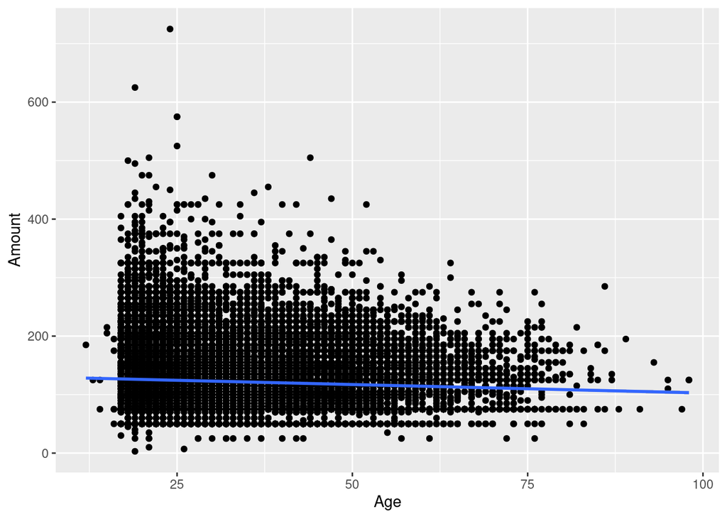

```r
# if we don't color
p1 <- ggplot(data = speed)+
  aes(x = Age, y = Amount)+
  geom_point()+
  geom_smooth(method = "lm")
p1
```

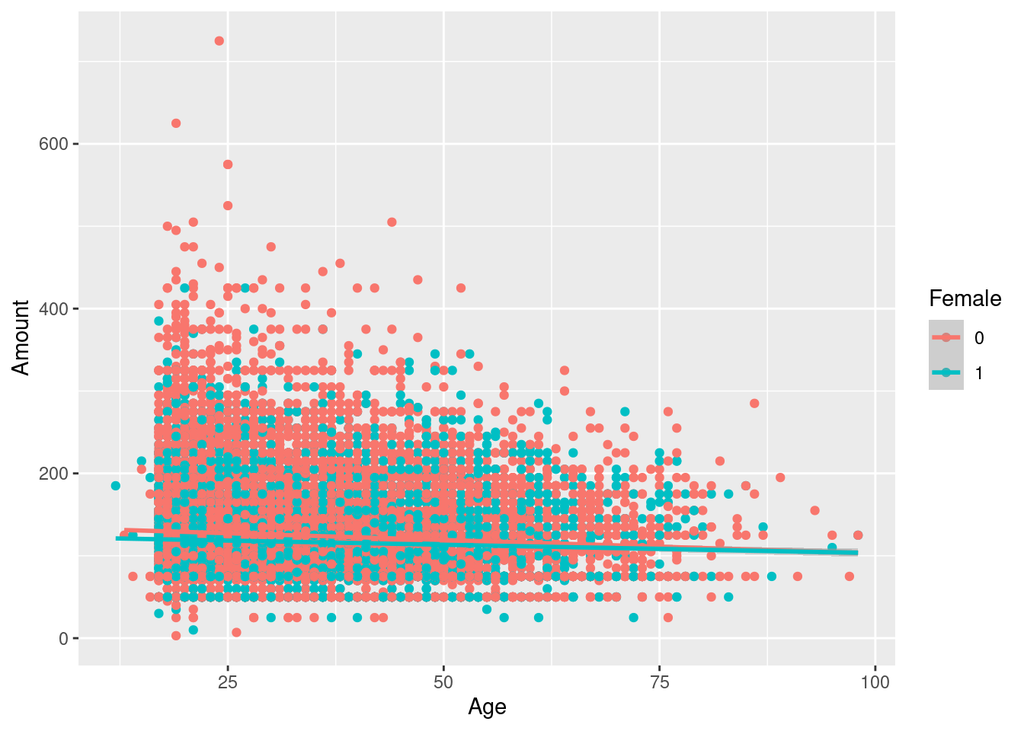

```r
# if we color by Female
p2 <- ggplot(data = speed)+
  aes(x = Age, y = Amount, color = Female)+
  geom_point()+
  geom_smooth(method = "lm")
p2
```

### Part G

Add a final facet layer to the plot make two different sub-plots by sex with `facet_wrap( ~ Female)`.

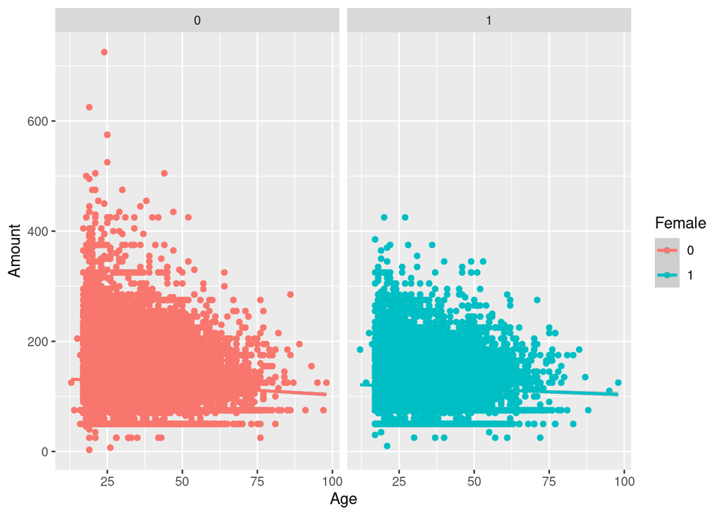

```r
p2+ facet_wrap(~Female)
```

## Question 8

Now let’s look at the possible interaction between sex (`Male` or `Female`) and whether a driver is from In-State or Out-of-State (`OutState`).

### Part A

Use `R` to examine the data and find the average fine for:

1. Males In-State
2. Males Out-of-State
3. Females In-State
4. Females Out-of-State

```r
# Summarize for Men in State

speed %>%
  filter(Female == 0,
         OutState == 0) %>%
  summarize(mean = mean(Amount))
```

| mean |
| --- |
| 123.6775 |

```r
# Summarize for Men Out of State

speed %>%
  filter(Female == 0,
         OutState == 1) %>%
  summarize(mean = mean(Amount))
```

| mean |
| --- |
| 127.969 |

```r
# Summarize for Women in State

speed %>%
  filter(Female == 1,
         OutState == 0) %>%
  summarize(mean = mean(Amount))
```

| mean |
| --- |
| 114.7985 |

```r
# Summarize for Women Out of State

speed %>%
  filter(Female == 1,
         OutState == 1) %>%
  summarize(mean = mean(Amount))
```

| mean |
| --- |
| 124.2657 |

### Part B

Now run a regression of the following model:

$$\widehat{\text{Amount}}_i=\hat{\beta_0}+\hat{\beta_1} \, \text{Female}_i+\hat{\beta_2} \, \text{OutState}_i+\hat{\beta_3} \, (\text{Female}_i \times \text{OutState}_i)$$

```r
sex_state_reg <- lm(Amount ~ Female + Female:OutState, data = speed)
summary(sex_state_reg)
```

```
Call:
lm(formula = Amount ~ Female + Female:OutState, data = speed)

Residuals:
    Min      1Q  Median      3Q     Max
-120.68  -48.68   -8.68   31.32  601.32

Coefficients:
                  Estimate Std. Error t value Pr(>|t|)
(Intercept)       123.6775     0.4391 281.650  < 2e-16 ***
Female1            -8.8790     0.7541 -11.775  < 2e-16 ***
Female0:OutState1   4.2915     0.9152   4.689 2.76e-06 ***
Female1:OutState1   9.4672     1.3586   6.968 3.27e-12 ***
---
Signif. codes:  0 '***' 0.001 '**' 0.01 '*' 0.05 '.' 0.1 ' ' 1

Residual standard error: 56.06 on 31670 degrees of freedom
Multiple R-squared:  0.006629,  Adjusted R-squared:  0.006535
F-statistic: 70.44 on 3 and 31670 DF,  p-value: < 2.2e-16
```

```r
tidy(sex_state_reg)
```

| term | estimate | std.error | statistic | p.value |
| --- | --- | --- | --- | --- |
| (Intercept) | 123.677526 | 0.4391179 | 281.649944 | 0.000000e+00 |
| Female1 | -8.879009 | 0.7540744 | -11.774711 | 6.143828e-32 |
| Female0:OutState1 | 4.291493 | 0.9152285 | 4.688985 | 2.757066e-06 |
| Female1:OutState1 | 9.467152 | 1.3586013 | 6.968307 | 3.270451e-12 |

### Part C

Write out the estimated regression equation.

### Part D

What does each coefficient mean?

### Part E

Using the regression equation, what are the average fine for

1. Males In-State
2. Males Out-of-State
3. Females In-State
4. Females Out-of-State

Compare to your answers in part A.

- Males In-State: $\hat{\beta_0}=\$123.68$
- Males Out-of-State: $\hat{\beta_0}+\hat{\beta_2}=123.68+4.29=\$127.97$
- Females In-State: $\hat{\beta_0}+\hat{\beta_1}=123.68-8.88=\$114.80$
- Females Out-of-State: $\hat{\beta_0}+\hat{\beta_1}+\hat{\beta_2}+\hat{\beta_3}=123.68-8.88+4.29+5.17=\$124.26$

## Question 9

Collect your regressions from questions 4, 5b, 7a, 7b, and 8b and output them in a regression table with `modelsummary()`.

```r
modelsummary(models = list(female_reg,
                           male_reg,
                           age_reg,
                           interact_reg,
                           sex_state_reg),
             fmt = 2, # round to 2 decimals
             output = "html",
             coef_rename = c("(Intercept)" = "Constant"),
             gof_map = list(
               list("raw" = "nobs", "clean" = "n", "fmt" = 0),
               list("raw" = "adj.r.squared", "clean" = "Adj. R<sup>2</sup>", "fmt" = 2),
               list("raw" = "rmse", "clean" = "SER", "fmt" = 2)
             ),
             escape = FALSE,
             stars = c('*' = .1, '**' = .05, '***' = 0.01)
)
```

|  | Model 1 | Model 2 | Model 3 | Model 4 | Model 5 |
| --- | --- | --- | --- | --- | --- |
| Constant | 124.67*** | 116.73*** | 134.20*** | 135.55*** | 123.68*** |
|  | (0.39) | (0.55) | (0.91) | (1.07) | (0.44) |
| Female1 | −7.94*** |  | −7.85*** | −12.02*** | −8.88*** |
|  | (0.67) |  | (0.67) | (1.89) | (0.75) |
| Male |  | 7.94*** |  |  |  |
|  |  | (0.67) |  |  |  |
| Age |  |  | −0.29*** | −0.33*** |  |
|  |  |  | (0.02) | (0.03) |  |
| Age:Female1 |  |  |  | 0.12** |  |
|  |  |  |  | (0.05) |  |
| Female0:OutState1 |  |  |  |  | 4.29*** |
|  |  |  |  |  | (0.92) |
| Female1:OutState1 |  |  |  |  | 9.47*** |
|  |  |  |  |  | (1.36) |
| n | 31674 | 31674 | 31674 | 31674 | 31674 |
| Adj. R<sup>2</sup> | 0.004 | 0.004 | 0.009 | 0.009 | 0.007 |
| SER | 56.12 | 56.12 | 56.00 | 56.00 | 56.06 |

* p < 0.1, ** p < 0.05, *** p < 0.01